# Dynamic ATAC-peaks in KRasG12D colonic epithelium using merged peaks

Bing Shui

2021-10-07

# Library loading and set up

```r
library(tidyverse)
library(DESeq2)
library(knitr)
library(kableExtra)
library(plyranges)
library(stringr)
library(biobroom)
library(ggrepel)
library(RColorBrewer)
library(gplots)
library(biomaRt)
library(ChIPseeker)
library(TxDb.Mmusculus.UCSC.mm10.knownGene)
library(mixOmics)
library(mosaic)
library(clusterProfiler)
library(DOSE)
library(org.Mm.eg.db)
library(pathview)
library(AnnotationDbi)
library(fgsea)
library(rvest)
library(ggseqlogo)
library(gridExtra)
library(rtracklayer)
library(Biostrings)
library(Rsamtools)
library(data.table)
library(grid)
library(apeglm)
```

# Load dataset

This dataset is generated using WT and KRas-G12D expressingn colonic epithelium from mouse. Mice user are - Fabp-Cre/+ - Fabp-Cre/+; KRasG12D/+

Alignment and peak calling was done using the `bcbio` ATAC-Seq pipeline following instructions described here: (https://bcbio-nextgen.readthedocs.io/en/latest/contents/atac.html)

Merged peak data are used here. This is obtained by combining all peaks from all samples, merging peaks within 500bp of each other, and using `featureCount` to count all reads in the peaks.

```r
metadata = readr::read_csv("Data/bcbio_output/metadata.csv") %>%
  dplyr::rename("sample"=...1) %>%
  dplyr::select(-batch, -phenotype) %>%
  dplyr::filter(tissue == "colon_epithelium") %>%
  dplyr::filter(sample != "Kras_colon_rep3") %>%
  mutate(condition=relevel(factor(condition), ref="WT")) %>%
  as.data.frame()
rownames(metadata) = metadata$sample
counts = readr::read_tsv("Data/bcbio_output/merged/merged-counts.tsv") %>%
  tibble::column_to_rownames("id")
```

Metadata

```r
metadata %>%
  kable() %>%
  kable_styling()
```

|  | sample | condition | replicate | tissue |
| --- | --- | --- | --- | --- |
| WT_colon_rep1 | WT_colon_rep1 | WT | rep1 | colon_epithelium |
| WT_colon_rep2 | WT_colon_rep2 | WT | rep2 | colon_epithelium |
| WT_colon_rep3 | WT_colon_rep3 | WT | rep3 | colon_epithelium |
| Kras_colon_rep1 | Kras_colon_rep1 | Kras | rep1 | colon_epithelium |
| Kras_colon_rep2 | Kras_colon_rep2 | Kras | rep2 | colon_epithelium |

Load Ensembl ID dataset

```r
ensembl = useMart("ensembl", dataset="mmusculus_gene_ensembl")
symbols = getBM(attributes=c("entrezgene_id", "mgi_symbol", "ensembl_gene_id"), mart=ensembl) %>%
  dplyr::rename("geneId"=entrezgene_id) %>%
  mutate(geneId=as.character(geneId))

save(symbols, file = "Data/symbols.rda")
```

# Cleanup

We need to do a little it of cleanup before contining. We need to remove peaks that appear in regions known to be false positive machines, called the blacklist regions. We also are interested in regions that could be affecting expression via chromatin accessability, so we’ll only consider peaks within a window around the transcription start sites of genes.

## Blacklist region removal

```r
load("Data/symbols.rda")

expand_region_string = function(df, column) {
  df = as.data.frame(df)
  tokens = str_split_fixed(df[,column], ":", 2)
  chrom = tokens[,1]
  start = as.numeric(str_split_fixed(tokens[,2], "-", 2)[, 1])
  end = as.numeric(str_split_fixed(tokens[,2], "-", 2)[, 2])
  regions = data.frame(seqnames=chrom, start=start, end=end)
  df %>%
    bind_cols(regions)
}
blacklist = readr::read_tsv("Data/mm10-blacklist.v2.bed.gz", col_names=c("seqnames", "start", "end")) %>%
  as_granges()
blacklist_peaks = counts %>%
  tibble::rownames_to_column("peak") %>%
  expand_region_string("peak") %>%
  as_granges() %>%
  join_overlap_inner(blacklist) %>%
  tidy() %>%
  pull(peak)
counts = counts[!rownames(counts) %in% blacklist_peaks, ]

counts <- counts[,-6]
```

A few peaks overlap the ENCODE blacklist regions, so we removed them from the analysis. There were 4897 that overlapped with the blacklist regions.

## Open region annotation

Here we annotate the peaks that we called with contextual genomic information. We can also see that some peaks are annotated in multiple regions, this can’t be helped as genes overlap so there are areas where multiple features of genes overlap.

```r
annotatedobj = ChIPseeker::annotatePeak(counts %>%
                                        tibble::rownames_to_column("peak") %>%
                                        expand_region_string("peak") %>%
                                        as_granges(), TxDb = TxDb.Mmusculus.UCSC.mm10.knownGene)
```

```
## >> preparing features information...      2021-10-07 18:36:01
## >> identifying nearest features...        2021-10-07 18:36:02
## >> calculating distance from peak to TSS...   2021-10-07 18:36:10
## >> assigning genomic annotation...        2021-10-07 18:36:10
## >> assigning chromosome lengths           2021-10-07 18:36:49
## >> done...                    2021-10-07 18:36:49
```

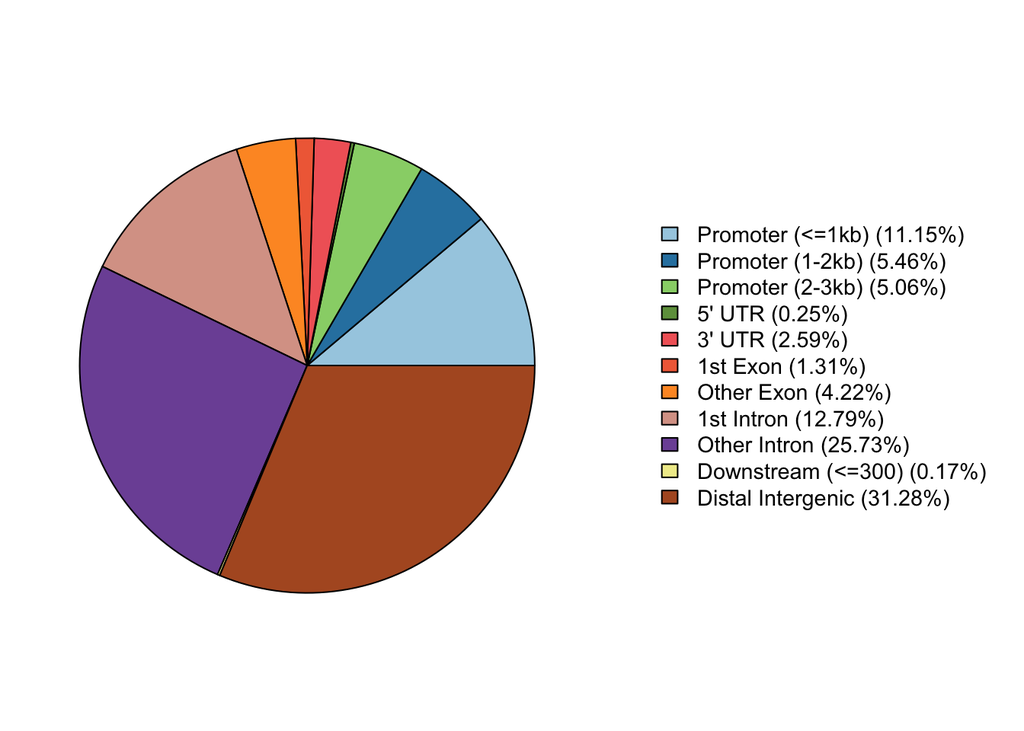

```r
plotAnnoPie(annotatedobj)
```

```r
pdf('PDF_Figure/Annotation_Pie.pdf',
    width = 6,
    height = 4)
plotAnnoPie(annotatedobj)
dev.off()
```

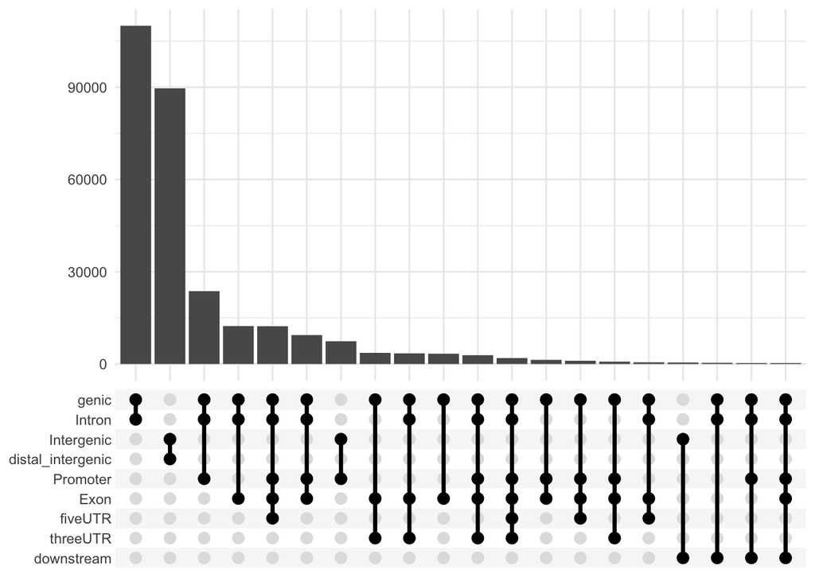

```r
upsetplot(annotatedobj)
```